# OSIC

```
ManufacturerModelName
```

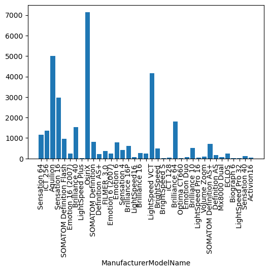

```python
categorical(20)
```

2 values, patient direction in rows and columns. Values include: A (anterior), P (posterior), RL, H (head), F (foot). So, LP = left posterior, LA = left anterior, RA = right anterior. Empty values just default to LP, cause it has a bunch more stuff in it

```
PatientOrientation
```

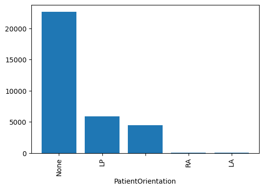

```python
categorical(24, apply(lambda r: "".join(r) if isinstance(r, list) else r))
```

Quite complex. Refer to docs for more

```
PatientPosition
```

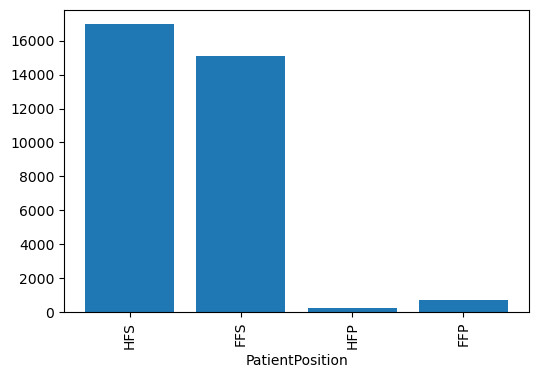

```python
categorical(25)
```

Pixel value to pad the background

```
PixelPaddingValue
```

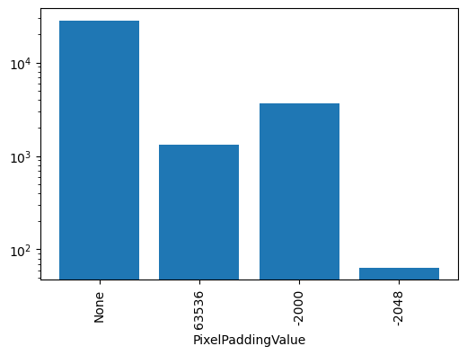

```python
categorical(28, apply(str)); plt.yscale("log");
```

What format are the pixels??? 0 and 1. Let's hope this is automatically handled on getting pixel_array

```
29 PixelRepresentation
```

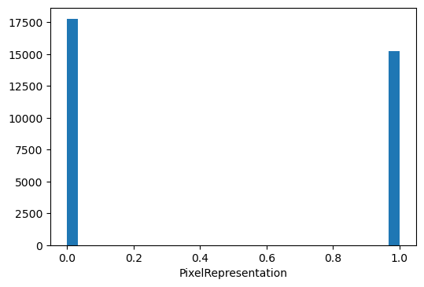

```python
plotHist(29)
```

x-y spacing between each pixels.

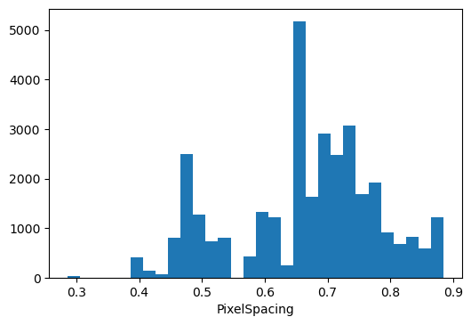

```python
plt.hist(ps() | cut(30) | toFloat(0) | cut(0) | toList(), bins=30); plt.xlabel(fields[30]);
```

x and y always equal to each other?

```python
all(ps() | cut(30) | toFloat(0, 1) | transpose() | equals())
```

```
True
```

Specifies part of the imaging target that was used as a reference point. Read docs for more

```
PositionReferenceIndicator
```

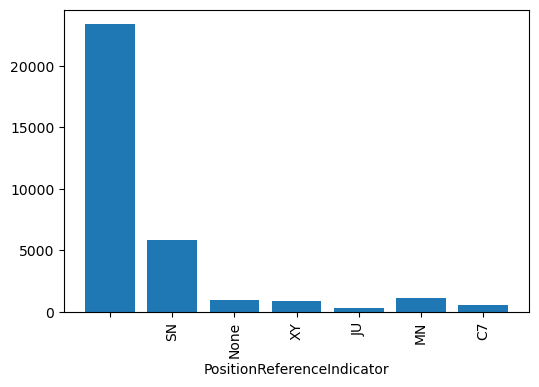

```python
categorical(31)
```

$output = m\cdot SV+b$, where SV is the stored value. Rescale slope is 1 for all images already btw.

```
32 RescaleIntercept
```

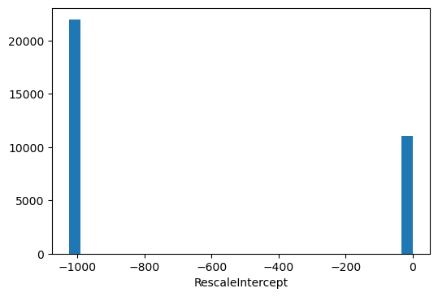

```python
plotHist(32)
```

Specifies output units of rescale slope and rescale intercept. HU = hounsfield units, US = unspecified. So all of these are just HU then lmao.

```
RescaleType
```

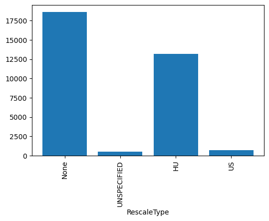

```python
categorical(34)
```

Time for the x-ray source to rotate around the patient. Kinda hard to believe that these things rotate 1 revolution per fucking 0.4 second??? That's so fast.

```
35 RevolutionTime
```

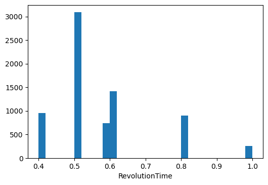

```python
plotHist(35)
```

Height of image

```
37 Rows
```

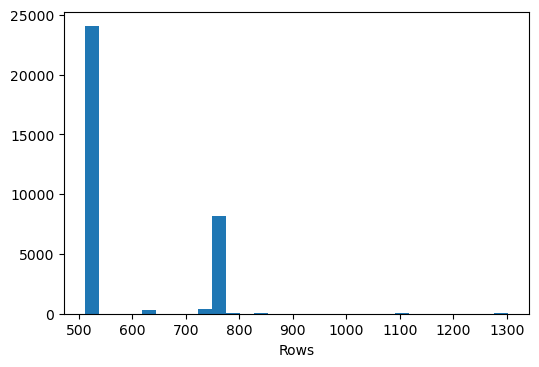

```python
plotHist(37)
```

This seems like a unique value for every dcm file

```python
ps() | cut(38) | filt(op() != None) | count() | ~sort() | display(4)
```

```
1   SOPInstanceUID                                0%
1   2.25.9463146288515712963633997841404523038    0%
1   2.25.65126428428746723320146291533300269472   0%
1   2.25.92410940641125329671602685303131497613   0%
```

This one's also full of weird numbers

```python
ps() | cut(40) | filt(op() != None) | count() | ~sort() | display(4)
```

```
1018   1.3.6.1.4.1.19291.2.1.2.1162211771921352226130345608929   3%
825    2.25.67300783861445963103644197317110142934               2%
602    1.3.6.1.4.1.19291.2.1.2.1162211771921352226130349723959   2%
577    2.25.168335002352647095587144455728050514290              2%
```

??

```
41 SingleCollimationWidth
```

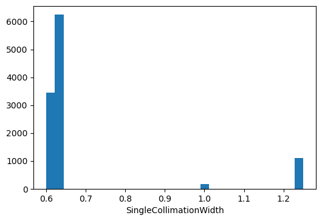

```python
plotHist(41)
```

I guess this is the locations? Note the tendency to center around 0, cause like, when the lung is exactly at the middle, it sort of should be zero in the comp.

```
42 SliceLocation
```

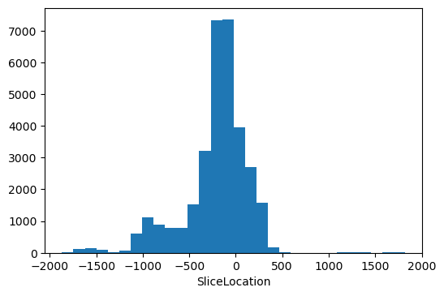

```python
plotHist(42)
```

Obv. This sort of means that distances below this threadhold are fused into 1 reading.

```
43 SliceThickness
```

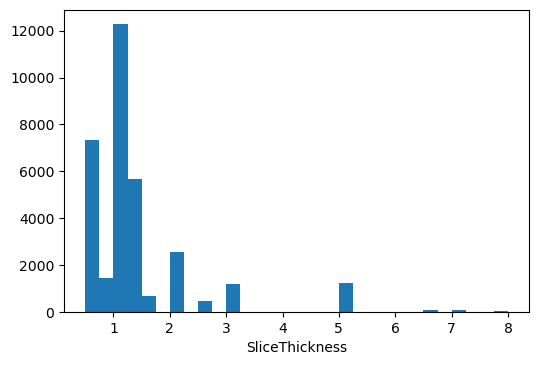

```python
plotHist(43)
```

Measured in mm. Kinda correspond to pixel spacing. This z axis is much less accurate though, which kinda sucks. Good thing a lot of them clumps toward 0. Also there shouldn't be any negative values here.

```
45 SpacingBetweenSlices
```

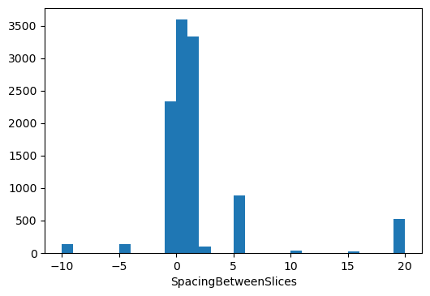

```python
plotHist(45)
```

The middle bar, expanded out

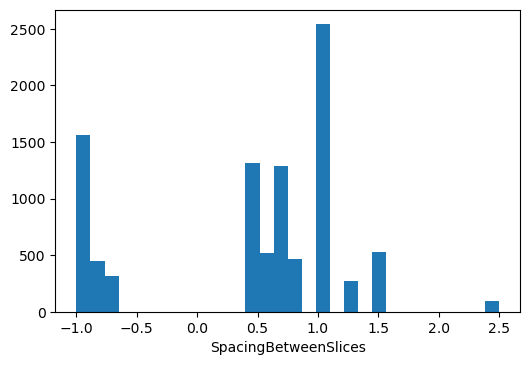

```python
a = np.array(ps() | cut(45) | filt(op() != None) | toFloat() | toList())
plt.hist(a[(a>-3) * (a<3)], bins=30); plt.xlabel(fields[45])
```

Resolution physics limitation in mm. 0.35 means that any further detail below 0.35mm is considered bogus.

```
46 SpatialResolution
```

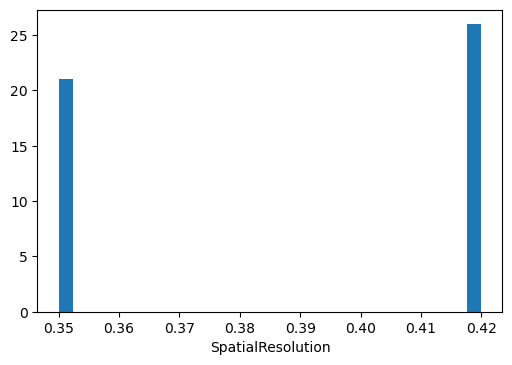

```python
plotHist(46)
```

Sort of unicode stuff?

```
SpecificCharacterSet
```

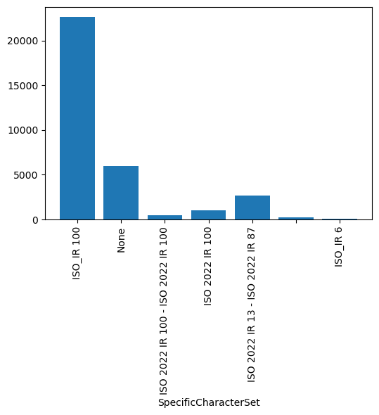

```python
categorical(47, apply(lambda r: " - ".join(r) if isinstance(r, list) else r))
```

Ah right, after the RevolutionTime thingy, this makes sense. I guess it's how much mm a full rotation will move? Sounds kinda like SpacingBetweenSlices though, so what's up with that? Official definition is `tableFeedPerRotation/totalCollimationWidth`. Should really be as close to 1 as possible to maximize image quality and efficiency.

```
48 SpiralPitchFactor
```

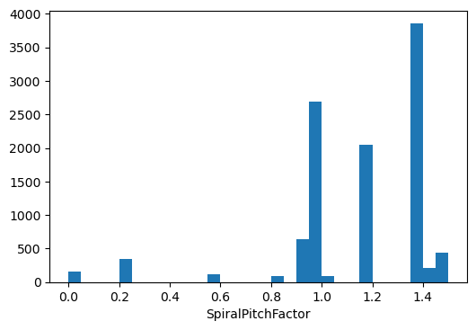

```python
plotHist(48)
```

Just to visualize, this is how the collimation thingy looks like. I guess these are independent x-ray sources that each gets their own detector? "C" is the total collimation width.

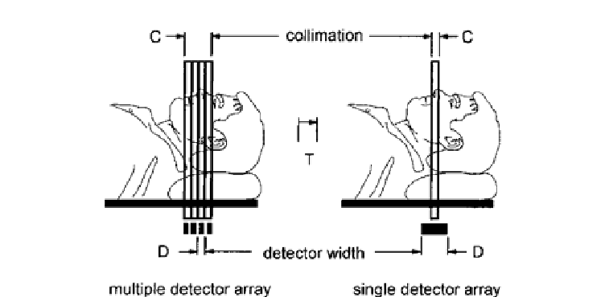

This one's also weird

```python
ps() | cut(50) | filt(op() != None) | count() | ~sort() | headOut()
```

```
[1018, '2.25.128099341455079131013013265801613167022', '3%']
[825, '2.25.44730338876702058263099469144293477993', '2%']
[602, '2.25.12038526814304474367356176974755630418', '2%']
[577, '2.25.168009088382578703118904593371568532454', '2%']
[574, '2.25.27570211803454260334890711816742630716', '2%']
[521, '2.25.21250775107781698674952036145409229511', '2%']
[512, '2.25.51524201997550974060815639537176759519', '2%']
[498, '2.25.138385002285841551528805699638475741461', '2%']
[497, '2.25.263916267626722293569390930007441210', '2%']
[493, '2.25.51234585641398128930095037592177078611', '1%']
```

Interesting question, does it always start with 2.25?

```python
ps() | cut(50) | op().split(".").all() | cut(0, 1) | join(".").all() | toFloat() | count() | display()
```

```
33026   2.25   100%
```

Yep, sure enough

This should sort of equal to total collimation width, because like, if it's much larger than that, then you get sparse spots in the image.

```
51 TableFeedPerRotation
```

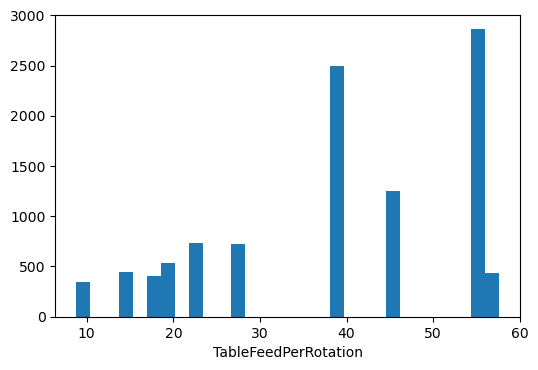

```python
plotHist(51)
```

Distance from table to center of rotation in mm. Should be 1/2 depth of human body (yep, this checks out). So kinda have to filter out negative values here, cause if so, the patient wouldn't be in the center anymore.

```
52 TableHeight
```

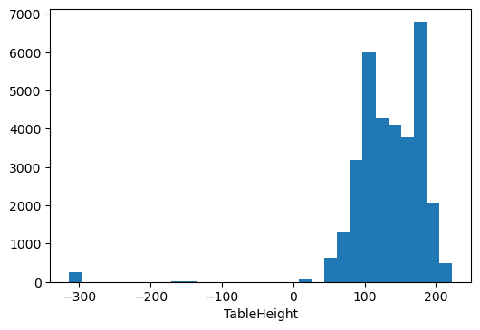

```python
plotHist(52)
```

```
53 TableSpeed
```

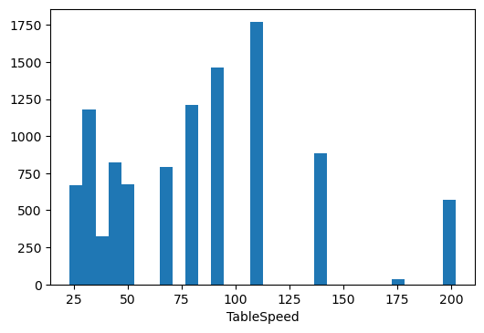

```python
plotHist(53)
```

```
54 TotalCollimationWidth
```

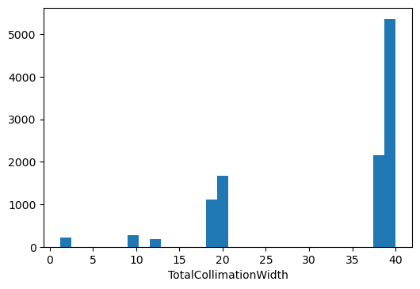

```python
plotHist(54)
```

Window center and window width is sort of like a filter for values. Anything below center - width/2 becomes min value, anything above center + width/2 becomes max value, and everything in the middle is scaled accordingly like this: $((x - c) / w + 0.5) * (max-min)$. This term $(x-c)/w + 0.5$ goes from 0 to 1, rest is pretty obvious.

```
WindowCenter
```

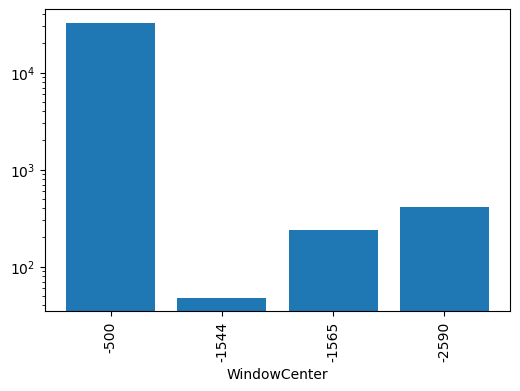

```python
categorical(55, instanceOf([str, float]) | toInt() | apply(str)); plt.yscale("log");
```

```
57 WindowWidth
```

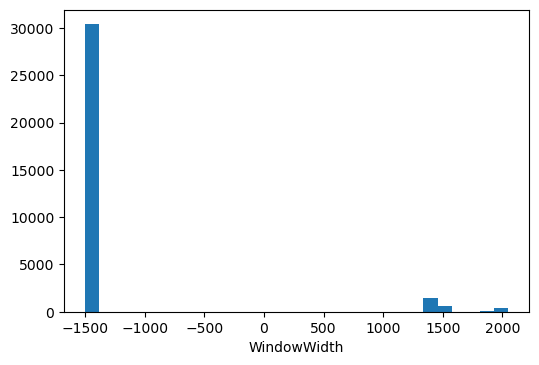

```python
plotHist(57, instanceOf([float, str]));
```

Tube current in mA

```
58 XRayTubeCurrent
```

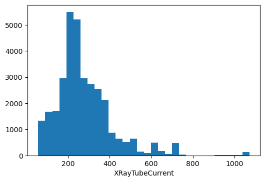

```python
plotHist(58)
```

Always clear pools after applyMp operation

```python
applyMp.clearPools()
```

```python
fields | insertIdColumn() | display(None)
```

```
0    BitsAllocated
1    BitsStored
2    BodyPartExamined
3    Columns
4    ConvolutionKernel
5    DeidentificationMethod
6    DistanceSourceToDetector
7    DistanceSourceToPatient
8    FocalSpots
9    FrameOfReferenceUID
10   GantryDetectorTilt
11   GeneratorPower
12   HighBit
13   ImageOrientationPatient
14   ImagePositionPatient
```

[output cut: 44 more lines]